# Prediction of Human Activity Recognition using K-nearest Neighbor (KNN)

Heping Zheng

December 27, 2015

```r
library(caret)
```

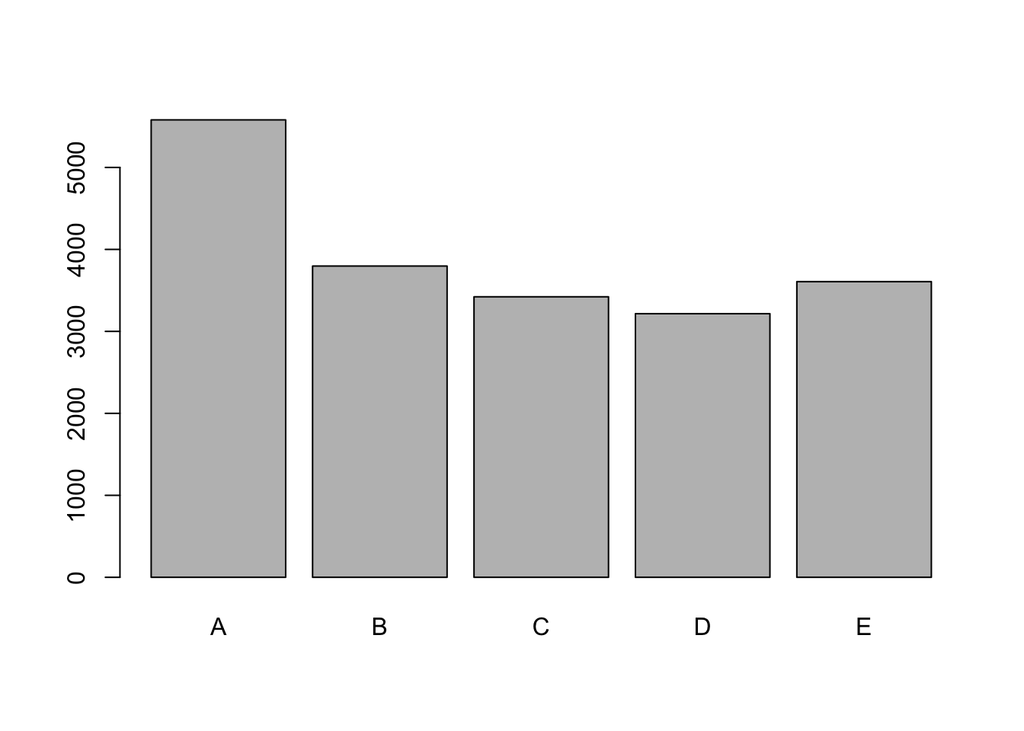

```r
setwd("/Users/dust/Courses/Coursera/ML")
pml_training <- read.csv("pml-training.csv")
pml_testing <- read.csv("pml-testing.csv")
barplot(table(pml_training$classe))
```

Next, we divided the dataset into 2/3 of training data and 1/3 of testing data which can be used for cross-validation.

```r
inTrain <- createDataPartition(y=pml_training$classe, p=0.66, list=FALSE)
training <- pml_training[inTrain,]
testing <- pml_training[-inTrain,]
```

The 2/3 trainng data are then used for building a model for prediction. Primitive feature selection involves manual inspection of the “summary” output of each variables, picking up the first 2 variables that appears to have diversity amongest the dataset: “roll belt” and “pitch belt”. K-nearest Neighbor is used for machine learning and prediction using these 2 features (modelFit). The results shows a IN-SAMPLE accuracy of ~75%, with the 95% CI : (0.7457, 0.7606). The OUT-OF-SAMPLE accuracy is ~69%, with 95% CI : (0.6794, 0.7017). This is pretty low. However, considering that only 2 features are used for such a prediction, the result is still quite encouraging.

```r
# belt, arm, dumbbell, forearm
modelFit <- train(classe~roll_belt+pitch_belt, data=training, method="knn")
predictions <- predict(modelFit, newdata=training)
confusionMatrix(predictions, training$classe) # in sample error rate
```

```
## Confusion Matrix and Statistics
##
##           Reference
## Prediction    A    B    C    D    E
##          A 3004  341  301  344  160
##          B  218 1772  169   84   82
##          C  226  251 1530  163   89
##          D  188   90  216 1451   51
##          E   47   53   43   81 1999
##
## Overall Statistics
##
##                Accuracy : 0.7532
##                  95% CI : (0.7457, 0.7606)
##     No Information Rate : 0.2843
##     P-Value [Acc > NIR] : < 2.2e-16
##
##                   Kappa : 0.6864
##  Mcnemar's Test P-Value : < 2.2e-16
##
## Statistics by Class:
##
##                      Class: A Class: B Class: C Class: D Class: E
## Sensitivity            0.8156   0.7068   0.6773   0.6835   0.8396
## Specificity            0.8764   0.9471   0.9318   0.9497   0.9788
## Pos Pred Value         0.7239   0.7622   0.6773   0.7270   0.8992
## Neg Pred Value         0.9229   0.9308   0.9318   0.9387   0.9644
## Prevalence             0.2843   0.1935   0.1744   0.1639   0.1838
## Detection Rate         0.2319   0.1368   0.1181   0.1120   0.1543
## Detection Prevalence   0.3204   0.1795   0.1744   0.1541   0.1716
## Balanced Accuracy      0.8460   0.8269   0.8046   0.8166   0.9092
```

```r
predictions <- predict(modelFit, newdata=testing)
confusionMatrix(predictions, testing$classe) # out of sample error rate
```

```
## Confusion Matrix and Statistics
##
##           Reference
## Prediction    A    B    C    D    E
##          A 1469  232  209  221   84
##          B  120  779  100   61   60
##          C  153  151  687   99   51
##          D  128   77  124  671   31
##          E   27   51   43   41 1000
##
## Overall Statistics
##
##                Accuracy : 0.6907
##                  95% CI : (0.6794, 0.7017)
##     No Information Rate : 0.2845
##     P-Value [Acc > NIR] : < 2.2e-16
##
##                   Kappa : 0.6064
##  Mcnemar's Test P-Value : < 2.2e-16
##
## Statistics by Class:
##
##                      Class: A Class: B Class: C Class: D Class: E
## Sensitivity            0.7744   0.6039   0.5907   0.6139   0.8157
## Specificity            0.8437   0.9366   0.9175   0.9354   0.9702
## Pos Pred Value         0.6632   0.6955   0.6021   0.6508   0.8606
## Neg Pred Value         0.9039   0.9079   0.9139   0.9252   0.9590
## Prevalence             0.2845   0.1934   0.1744   0.1639   0.1838
## Detection Rate         0.2203   0.1168   0.1030   0.1006   0.1499
## Detection Prevalence   0.3321   0.1679   0.1711   0.1546   0.1742
## Balanced Accuracy      0.8090   0.7702   0.7541   0.7747   0.8929
```

Further feather selection is done by manual inspaection of the “summary” of all 160 variables. Most variables are monotonous and has a lot of empty values, and are not selected as predictors. Some other variables are more complicated and involving X,Y,Z coordinates of movements, these variables are not used too due to complexities. Upon feature selection, I eventually chose only 16 variables to build the complete model, which are roll, pitch, yaw, and total accelaration of belt, arm, dumbbel, and forearm.

The same training dataset used to build the first model is used to build the second model, while the same testing dataset used to cross-validation the first model is also used to cross-validation the second model.

The In-sample error rate is 4.28%, while the In-sample accuracy is 95.72%, and the corresponding 95% CI is (0.9536, 0.9606)

The Out-of-sample error rate is 7.78%, while the Out-of-sample accuracy is 92.22%, and the corresponding 95% CI is (0.9155, 0.9285)

In fact, this is the model (modelFit2) that get 19 out of 20 test cases correct.

```r
modelFit2 <- train(classe~roll_belt+pitch_belt+yaw_belt+total_accel_belt+
                       roll_arm+pitch_arm+yaw_arm+total_accel_arm+
                       roll_dumbbell+pitch_dumbbell+yaw_dumbbell+total_accel_dumbbell+
                       roll_forearm+pitch_forearm+yaw_forearm+total_accel_forearm, data=training, method="knn") # second model with 16 predictors
predictions <- predict(modelFit2, newdata=training)
confusionMatrix(predictions, training$classe) # in sample error rate
```

```
## Confusion Matrix and Statistics
##
##           Reference
## Prediction    A    B    C    D    E
##          A 3616   39    7    2    2
##          B   37 2336   33   17   24
##          C   15   83 2149   86   24
##          D   11   19   55 2000   33
##          E    4   30   15   18 2298
##
## Overall Statistics
##
##                Accuracy : 0.9572
##                  95% CI : (0.9536, 0.9606)
##     No Information Rate : 0.2843
##     P-Value [Acc > NIR] : < 2.2e-16
##
##                   Kappa : 0.9459
##  Mcnemar's Test P-Value : 1.772e-06
##
## Statistics by Class:
##
##                      Class: A Class: B Class: C Class: D Class: E
## Sensitivity            0.9818   0.9318   0.9513   0.9421   0.9651
## Specificity            0.9946   0.9894   0.9805   0.9891   0.9937
## Pos Pred Value         0.9864   0.9546   0.9118   0.9443   0.9717
## Neg Pred Value         0.9928   0.9837   0.9896   0.9886   0.9922
## Prevalence             0.2843   0.1935   0.1744   0.1639   0.1838
## Detection Rate         0.2792   0.1803   0.1659   0.1544   0.1774
## Detection Prevalence   0.2830   0.1889   0.1820   0.1635   0.1826
## Balanced Accuracy      0.9882   0.9606   0.9659   0.9656   0.9794
```

```r
predictions <- predict(modelFit2, newdata=testing)
confusionMatrix(predictions, testing$classe) # out of sample error rate
```

```
## Confusion Matrix and Statistics
##
##           Reference
## Prediction    A    B    C    D    E
##          A 1811   38   11    1    4
##          B   53 1142   34   13   23
##          C   14   62 1077   67   28
##          D   16   14   26  983   34
##          E    3   34   15   29 1137
##
## Overall Statistics
##
##                Accuracy : 0.9222
##                  95% CI : (0.9155, 0.9285)
##     No Information Rate : 0.2845
##     P-Value [Acc > NIR] : < 2.2e-16
##
##                   Kappa : 0.9016
##  Mcnemar's Test P-Value : 4.179e-07
##
## Statistics by Class:
##
##                      Class: A Class: B Class: C Class: D Class: E
## Sensitivity            0.9547   0.8853   0.9261   0.8994   0.9274
## Specificity            0.9887   0.9771   0.9689   0.9839   0.9851
## Pos Pred Value         0.9710   0.9028   0.8630   0.9161   0.9335
## Neg Pred Value         0.9821   0.9726   0.9841   0.9803   0.9837
## Prevalence             0.2845   0.1934   0.1744   0.1639   0.1838
## Detection Rate         0.2716   0.1712   0.1615   0.1474   0.1705
## Detection Prevalence   0.2797   0.1897   0.1871   0.1609   0.1826
## Balanced Accuracy      0.9717   0.9312   0.9475   0.9416   0.9563
```

```r
modelFit3 <- train(classe~user_name+roll_belt+pitch_belt+yaw_belt+total_accel_belt+
                       roll_arm+pitch_arm+yaw_arm+total_accel_arm+
                       roll_dumbbell+pitch_dumbbell+yaw_dumbbell+total_accel_dumbbell+
                       roll_forearm+pitch_forearm+yaw_forearm+total_accel_forearm, data=pml_training, method="knn")
predictions <- predict(modelFit3, newdata=training)
confusionMatrix(predictions, training$classe) # in sample error rate
```

```
## Confusion Matrix and Statistics
##
##           Reference
## Prediction    A    B    C    D    E
##          A 3636   31    3    1    1
##          B   29 2394   24   14   20
##          C   10   55 2174   54   21
##          D    6   14   47 2042   20
##          E    2   13   11   12 2319
##
## Overall Statistics
##
##                Accuracy : 0.97
##                  95% CI : (0.967, 0.9729)
##     No Information Rate : 0.2843
##     P-Value [Acc > NIR] : < 2.2e-16
##
##                   Kappa : 0.9621
##  Mcnemar's Test P-Value : 0.002604
##
## Statistics by Class:
##
##                      Class: A Class: B Class: C Class: D Class: E
## Sensitivity            0.9872   0.9549   0.9624   0.9618   0.9740
## Specificity            0.9961   0.9917   0.9869   0.9920   0.9964
## Pos Pred Value         0.9902   0.9649   0.9395   0.9591   0.9839
## Neg Pred Value         0.9949   0.9892   0.9920   0.9925   0.9941
## Prevalence             0.2843   0.1935   0.1744   0.1639   0.1838
## Detection Rate         0.2807   0.1848   0.1678   0.1576   0.1790
## Detection Prevalence   0.2835   0.1915   0.1786   0.1644   0.1820
## Balanced Accuracy      0.9917   0.9733   0.9746   0.9769   0.9852
```

```r
predictions <- predict(modelFit3, newdata=testing)
confusionMatrix(predictions, testing$classe) # out of sample error rate
```

```
## Confusion Matrix and Statistics
##
##           Reference
## Prediction    A    B    C    D    E
##          A 1857   13    2    0    2
##          B   27 1243   10    5    9
##          C    7   28 1140   22   13
##          D    5    2    9 1060    9
##          E    1    4    2    6 1193
##
## Overall Statistics
##
##                Accuracy : 0.9736
##                  95% CI : (0.9695, 0.9773)
##     No Information Rate : 0.2845
##     P-Value [Acc > NIR] : < 2.2e-16
##
##                   Kappa : 0.9666
##  Mcnemar's Test P-Value : 2.681e-05
##
## Statistics by Class:
##
##                      Class: A Class: B Class: C Class: D Class: E
## Sensitivity            0.9789   0.9636   0.9802   0.9698   0.9731
## Specificity            0.9964   0.9905   0.9873   0.9955   0.9976
## Pos Pred Value         0.9909   0.9606   0.9421   0.9770   0.9892
## Neg Pred Value         0.9917   0.9913   0.9958   0.9941   0.9940
## Prevalence             0.2845   0.1934   0.1744   0.1639   0.1838
## Detection Rate         0.2785   0.1864   0.1709   0.1589   0.1789
## Detection Prevalence   0.2810   0.1940   0.1814   0.1627   0.1808
## Balanced Accuracy      0.9877   0.9770   0.9838   0.9827   0.9853
```

Finally I am writing out the predictions to the 20 files using the second and the third model. Upon “Prediction Assignment Submission” the second model is able to achieve 95% prediction accuracy on the blind test (19 out od 20), while the third model is able to achieve 100% prediction accuracy (20 out of 20) on the blind test of 20 samples.

```r
predictions <- predict(modelFit2, newdata=pml_testing)
predictions <- predict(modelFit3, newdata=pml_testing)
pml_write_files = function(x){
  n = length(x)
  for(i in 1:n){
    filename = paste0("problem_id_",i,".txt")
    write.table(x[i],file=filename,quote=FALSE,row.names=FALSE,col.names=FALSE)
  }
}
pml_write_files(predictions)
```